# Investigating factors of WA highway crashes

### Yidan Hu, Yuanjie Tu, Shuyi Yin, Shujun Zhou (Group 5)

#### CET 521 Inferential Data Analysis for Engineers

## The problem

### What factors are associated with single vehicle accidents?

- Why and how are people getting themselves into trouble?

## Exploratory analysis

[HSIS data](https://www.hsisinfo.org/index.cfm)

### Crash type

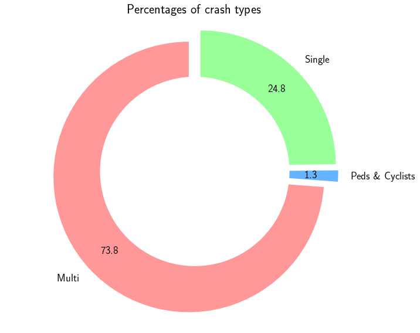

```python
fig
```

### We picked a type...

#### Strikes Appurtenance

#### It's coded as *type 33* in HSIS databases. As per [TRB](http://onlinepubs.trb.org/Onlinepubs/trr/1981/796/796.pdf) and [NCHRP](http://onlinepubs.trb.org/Onlinepubs/nchrp/nchrp_rpt_230.pdf):

Appurtenances covered by these procedures are

- longitudinal barriers such as bridge rails, guardrails, median barriers, transitions, and terminals;
- crash cushions;
- breakaway or yielding supports for signs anci iuminaires.

### Our model

- Response variable: severity level (PDO/ INJ/ FAT);
- Independent variable:
  - Driver and vehicle: driver sex, driver age, intoxication, vehicle year, vehicle type;
  - Roadway: curvature, grade, segment length, road surface material, shoulder and median material and width;
  - Accident-specific: time, location, weather, light, road surface condition when accident took place;

| Variable | Description | possible values |
| --- | --- | --- |
| Weekday | Day of week when the accident occurred. Further transformed into an indicator function. | 1: Yes, 0: No |
| Peak-hour | If accident took place in peak hours, i.e. 7-10am, 5-8pm | 1: Yes, 0: No |
| Light | The type/level of light that existed at the time of the crash | 1: Daylight 2: Dawn 3: Dusk 4: Dark |
| Roadway surface condition | The condition of the road surface where the crash occurred | 1:Dry 2:Wet 3:Snow/Slush 4:Ice 5:Other |
| driver sex | Driver sex | 1: Female 0: Male or unknown |
| young driver | If driver is younger than 25 years old | 1: Yes, 0: No |
| old driver | If driver is older than 65 years old | 1: Yes, 0: No |
| drunk driver | If driver had been drinking and ability had been impaird | 1: Yes, 0: No |
| Truck | If the involved vehicle is truck | 1: Yes, 0: No |
| Old car | If the involved vehicle was more than 15 years old at the time of crash | 1: Yes, 0: No |
| Rural/ Urban | Rural/ Urban indicator | R: Rural, U: Urban |
| Rd surface material | Surface material type | A: Asphalt B: Bituminous G: Gravel O: Other P: Portland Concrete Cem S: Soil |
| lane width | Calculate lane width, dividing total roadway width by num of lanes | continuous, in ft |
| Roadway width | Total roadway width for the roadway segment | continuous |
| degree of curvature | Degree of curvature for the curve, calculated from curve radius | continuous, in ft |
| grade percentage | Percent grade for this roadway segment | continuous, in % |
| AADT | Calculated Annual average daily traffic (AADT) | integer |
| Truck percentage in traffic | Truck percentage for the roadway segment | continuous, in % |
| mvmt | Million vehicle miles traveled on road segment. | continuous, in veh-mile |

## Data manipulation

### Initial steps

- Summarize and regroup categorical variables;
- Select possibly relevant variables from a original long list and drop those with too many missing values;

### Balance dataset

- **Property damage only (PDO)** -> **Injury (INJ)**: Random sampling;
- **Fatality (FAT)** -> **Injury (INJ)**: SMOTE Algorithm (oversampling by generating synthetic data);

Balanced dataset has size $$n_{\textrm{INJ}}\times3=4843\times3=14,529$$

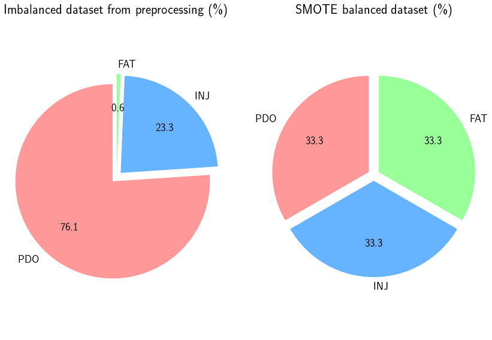

```python
fig
```

#### Dataset fed into models

See the first 5 observations to have a general idea.

```python
df_pre.head()
```

|  | Severity | driver sex | young driver | old driver | drunk driver | Truck | Old car | Rural/Urban | Lane width | Roadway width | degree of curvature | grade percentage | AADT | Truck percentage in traffic | mvmt | Weekday | Peak-hour | Light | Roadway Surface Condition | Rd Surface Material |
| --- | --- | --- | --- | --- | --- | --- | --- | --- | --- | --- | --- | --- | --- | --- | --- | --- | --- | --- | --- | --- |
| 0 | 1 | 0 | 1 | 0 | 1 | 0 | 1 | U | 12 | 96 | 0.75 | 0.08 | 172141.0 | 7.70 | 3.77 | 0 | 0 | 4 | 1 | A |
| 1 | 1 | 0 | 0 | 1 | 0 | 1 | 1 | U | 12 | 70 | 0.00 | 2.83 | 184453.0 | 0.00 | 0.67 | 1 | 0 | 1 | 2 | P |
| 2 | 1 | 1 | 1 | 0 | 0 | 0 | 0 | R | 12 | 72 | 0.00 | 1.55 | 56457.0 | 16.77 | 10.92 | 0 | 0 | 1 | 1 | A |
| 3 | 1 | 0 | 0 | 0 | 0 | 0 | 0 | U | 16 | 64 | 0.00 | 2.20 | 19480.0 | 5.46 | 0.50 | 1 | 1 | 1 | 1 | A |
| 4 | 1 | 0 | 0 | 0 | 0 | 0 | 0 | U | 12 | 48 | 0.00 | 0.93 | 71999.0 | 0.00 | 4.99 | 0 | 0 | 1 | 1 | A |

## Modeling and Results

#### Multinomial

- Added interaction terms, e.g. **drunk * young**;
- Removed several variables that might be too micro: material and widths of shoulder and medium;
- Response variable reference is **Fatality (FAT)**, category 3;

Accident severity level: (*PDO/INJ/FAT*) ~

- *driver sex + young driver + old driver + drunk driver + drunk driver* * *young driver* +
- *truck + old car* +
- *rural/ urban + lane width + roadway width + degree of curvature + grade percentage + AADT + truck percentage in traffic + mvmt* +
- *weekday + peak-hour + light conditinos + road surface condition* * *roadway surface material*

#### Some of our hypotheses:

- Driver sobriety (**drunk**): drivers who had been drinking and especially who had impaired ability are more likely to be involved in more severe crashes;
- Vehicle type (**truck**): strikes on appurtenance by trucks must be a lot more severe than passenger vehicles, because trucks have greater momentums;
- Light condition (**LIGHT**): more severe crashes are more likely to take place in darker conditions;
- Rural/ Urban roads (**RURURB**): rural roads in general have worse protection, and thus are more likely to have more severe crashes;
- Road surface condition (**RDSURF**): The more slippery it is, the more severe the accident is likely to be;
- Interaction of **drunk** and **young driver** (**drunk * young**): young drivers who had been drinking are red alerts for severe crashes. Lack of experience is magnified by impaired abilities;

#### Model results

AIC(multinomial) = 24,211

##### Driver

- Female driver are more likely to be involved in less severe crashes;
- *Young* drivers (< 25 years of age), compared to others, are more likely to see less severe crashes;
- *Old* drivers (> 65 years of age), compared to others, are more likely to see less severe crashes;
- That said, the people in the middle (25 < age < 65) are likely to see more severe crashes;
- *Drunk* drivers are more likely to see more severe crahes, like fatal;
- *Drunk* *young drivers* are more likely to see less severe crashes;

| Variables | Coefficients | p-value |
| --- | --- | --- |
| **driver sex** *Female*:1 | 1.303e+00 | < 2e-16 *** |
| **driver sex** *Female*:2 | 1.738e+00 | < 2e-16 *** |
| **young driver** *True*:1 | 1.783e+00 | < 2e-16 *** |
| **young driver** *True*:2 | 1.763e+00 | < 2e-16 *** |
| **old driver** *True*:1 | 9.616e-01 | 2.89e-15 *** |
| **old driver** *True*:2 | 1.196e+00 | < 2e-16 *** |
| **drunk driver** *True*:1 | -6.914e-01 | 2.52e-16 *** |
| **drunk driver** *True*:2 | -2.285e-01 | 0.003188 ** |
| **young driver** *True* : **drunk** *True*:1 | 2.514e+00 | 1.05e-08 *** |
| **young driver** *True* : **drunk** *True*:2 | 2.609e+00 | 1.92e-09 *** |

##### Vehicle

- *Trucks* are more likely to see more severe crashes;
- *Old cars* tend to witness less severe crahes;

| Variables | Coefficients | p-value |
| --- | --- | --- |
| **Truck** *True*:1 | -9.207e-01 | < 2e-16 *** |
| **Truck** *True*:2 | -2.947e-01 | 0.000159 *** |
| **Old car** *True*:1 | 3.208e-01 | 1.39e-08 *** |
| **Old car** *True*:2 | 4.326e-01 | 6.05e-15 *** |

##### Road

- *Urban* roads are more likely to have less severe crashes, or equivalently, rural roads are more dangerous;
- The wider the lanes are, the more likely a crash would be less severe;
- Ohter roadway features are not contributing much;

| Variables | Coefficients | p-value |
| --- | --- | --- |
| **Rural/ Urban** *Urban*:1 | 9.073e-01 | < 2e-16 *** |
| **Rural/ Urban** *Urban*:2 | 7.809e-01 | < 2e-16 *** |
| **Lane width**:1 | 1.006e-01 | 8.82e-09 *** |
| **Lane width**:2 | 1.206e-01 | 3.04e-12 *** |
| **Roadway width**:1 | 3.608e-04 | 0.869429 |
| **Roadway width**:2 | -1.784e-03 | 0.411822 |
| **degree of curvature**:1 | 1.189e-02 | 0.025466 * |
| **degree of curvature**:2 | 2.029e-02 | 3.03e-05 *** |
| **grade percentage**:1 | 6.779e-04 | 0.057607 . |
| **grade percentage**:2 | 8.743e-04 | 0.014120 * |
| **AADT**:1 | 2.301e-07 | 0.790135 |
| **AADT**:2 | 3.054e-06 | 0.000311 *** |
| **Truck percentage in traffic**:1 | 8.624e-03 | 0.049706 * |
| **Truck percentage in traffic**:2 | 3.396e-03 | 0.435586 |
| **mvmt**:1 | 1.439e-02 | 0.000970 *** |
| **mvmt**:2 | 6.747e-03 | 0.122623 |

##### Environmental conditions

- Crashes on *weekday* (vs. weekends) are more likely to be more severe;
- Crashes in *peak-hour* are in general less severe;
- Some light will help, as in *daylihgt*, *dawn*, *dusk*, crashes are more likely to be less severe, while *dark* is more likely to witness severe fatal crashes;
- All road conditions, including *wet*, *snow* and *ice*, are likely to have less severe crashes. However, *Portland Concrete Cemt* when *wet* sees particularly less severe crashes, compared to fatal;

| Variables | Coefficients | p-value |
| --- | --- | --- |
| **Weekday** *True*:1 | -5.565e-01 | < 2e-16 *** |
| **Weekday** *True*:2 | -6.472e-01 | < 2e-16 *** |
| **Peak-hour** *True*:1 | 1.371e+00 | < 2e-16 *** |
| **Peak-hour** *True*:2 | 1.299e+00 | < 2e-16 *** |
| **Light** *Dawn*:1 | 3.698e+00 | 3.90e-07 *** |
| **Light** *Dawn*:2 | 3.717e+00 | 3.32e-07 *** |
| **Light** *Dusk*:1 | 3.586e+00 | 3.92e-09 *** |
| **Light** *Dusk*:2 | 3.464e+00 | 1.21e-08 *** |
| **Light** *Dark*:1 | -4.870e-01 | < 2e-16 *** |
| **Light** *Dark*:2 | -5.184e-01 | < 2e-16 *** |
| **Roadway Surface Condition** *Wet*:1 | 1.953e+00 | < 2e-16 *** |
| **Roadway Surface Condition** *Wet*:2 | 1.714e+00 | < 2e-16 *** |
| **Roadway Surface Condition** *Snow/Slush*:1 | 6.662e+00 | 3.44e-11 *** |
| **Roadway Surface Condition** *Snow/Slush*:2 | 5.901e+00 | 4.67e-09 *** |
| **Roadway Surface Condition** *Ice*:1 | 5.652e+00 | 3.38e-15 *** |
| **Roadway Surface Condition** *Ice*:2 | 5.145e+00 | 8.79e-13 ** |
| **Roadway Surface Condition** *Wet* : **Rd Surface Material** *Portland Cem*:1 | 8.983e-01 | 2.28e-05 *** |
| **Roadway Surface Condition** *Wet* : **Rd Surface Material** *Portland Cem*:2 | 8.824e-01 2 | 3.15e-05 *** |

#### Did that validate our guesses?

- Almost everything is what we expected. Except **the following two**;
- Road surface at the crash scene is not very informative. It says *Wet*, *Snow/Slush* and *Ice* conditions are more likely to witness less severe crashes;
- **Drunk * young** interaction term is not warning us against the danger of drunk young driver;

##### Why?

- Complex interactions:
  - Compared to more inclusive models, we know interactions are missing;
    - Diffrent road surface materials may have different behaviors under different conditions. It's very likely that when **wet** (instead of **standing water**), some materials produce better friction. This is what we observed for *Portland Concrete Cemt*;
- Insufficient data:
  - Some important info is impossible to collect;
    - For example, speed of vehicle before crash is an important factor. Since we may acquire flow speed from sensors, how much faster the vehicle is travelling can largely impact the severity. However, it was almost impossible to collect such data;
  - When recorded as categorical, attributes lose the level of detail to be modeled by more complex link functions;
- Data quality control:
  - In general the dataset is well maintained. However, some problems still exist. Variables can take values not specified in the guidebook, the most common being *10* often coded as *.* (period). Another problem is the coding of **vehicle type**, where the WA file is not explicitly writing out the codings. Yet another is absence of data for some variables: nothing returned even the guidebook says the variables are recorded.
  - Considering these issues, the quality of dataset can be further enhanced. Maybe that can answer some of our confusions from the multinomial modeling.

## Conclusions

WA highway crashes are complex interplays of many variables. It's hard to model completely using multinomial logit regression. Among the available and applied variables, we summarize influences of some for each category into single sentences.

- Driver:
  - Male, aged 25 - 65, drunk drivers are more likely to see more severe accidents;
- Vehicle:
  - New vehicle and trucks are more likely to be involved in more severe crashes;
- Roadway:
  - Rural roadway segments with narrower lanes and less traffic are more likely to witness more severe crashes;
- Accident specific:
  - Weekdays at non peak-hour and especially when it's dark but not slippery on road surfaces are more likely to have more severe crashes;

### Limitations

- Lack important variables (e.g. speed at crash);
- Some potential underlying interaction effects not included;
- Highly imbalanced dataset;

## Q&A

Thank you for your attention!